# Medicare at 65: Sharp RD Identification

Checking the continuity assumption before estimating the effect

# 1 Research design and identifying assumption

## 1.1 Question and estimand

We ask how becoming eligible for Medicare at 65 changes healthcare use in the United States. The sharp RD estimand is the gap in expected outcomes just above and just below the cutoff:

$$\tau_{RD}=\lim_{a\downarrow 65}E[Y_i\mid
Age_i=a]-\lim_{a\uparrow 65}E[Y_i\mid Age_i=a].$$

Treatment is **eligibility**, $D_i=1(Age_i\ge65)$, not Medicare coverage. $\tau_{RD}$ is therefore an intention-to-treat effect of eligibility for people near 65. The main outcome is seeing a doctor in the past year (`sawdr`); an overnight hospital stay (`inhosp`) is secondary. Self-rated health is not used, because Medicare can change it.

This report checks the design only. **It does not estimate the jump in either outcome at 65.** Those estimates and their robustness checks are in `sharp_rd_estimation.Rmd`.

## 1.2 The identifying assumption

**Continuity.** $E[Y_i(0)\mid Age_i=a]$ and $E[Y_i(1)\mid Age_i=a]$ are continuous at $a=65$ (Hahn, Todd and van der Klaauw, 2001; Card, Dobkin and Maestas, 2008).

In words: without the Medicare rule, healthcare use would change smoothly as people pass 65. An independent change at 65 that affects healthcare use, or a discontinuous change in who is in the sample, would threaten attribution to Medicare eligibility.

Continuity involves potential outcomes, so it cannot be tested directly. We test what it implies. Characteristics fixed before 65 should be smooth through the cutoff. Nobody should be sorted across it. Survey response should not change at 65. No other determinant of healthcare use, retirement in particular, should jump there.

## 1.3 Why the assumption is plausible

- **Age cannot be manipulated.** Unlike test scores or income, nobody can choose which side of 65 they are on.
- **Local comparability.** People on either side of the cutoff differ in age by a few months.
- **Eligibility is a strict function of age.** Medicare eligibility begins at 65 for nearly everyone with a work history, so the rule itself does not create selection.

## 1.4 Eligibility coding

Age (`age4`) is recorded in quarter-year units. The eligibility indicator `post65` is exactly $1(age4\ge65)$ for every respondent. This confirms the coding, not each respondent’s exact birthday or legal eligibility.

| Age | Respondents | Coded eligible | Whole-year age below 65 | Medicare coverage |
| --- | --- | --- | --- | --- |
| 64.00 | 918 | 0% | 902 | 12.7% |
| 64.25 | 887 | 0% | 828 | 15.9% |
| 64.50 | 894 | 0% | 789 | 22.5% |
| 64.75 | 964 | 0% | 754 | 30.1% |
| 65.00 | 923 | 100% | 296 | 66.5% |
| 65.25 | 972 | 100% | 17 | 84.3% |
| 65.50 | 918 | 100% | 1 | 87.9% |
| 65.75 | 887 | 100% | 0 | 90.6% |
| 66.00 | 959 | 100% | 0 | 89.4% |

Two features of the data make the cutoff less than perfectly sharp. Both are handled in the estimation report.

1. **Quarter-age coding can blur the threshold.** Without exact dates, respondents coded 65.00 may be on either side of their actual birthday. In this cell, 296 of 923 respondents have a whole-year age below 65, and Medicare coverage is 66.5%. Across the sample, the quarter-age rule and the whole-year age disagree for 704 respondents. Neither measure is exact, so the estimation report checks sensitivity by dropping the 65.00 cell.
2. **The outcomes look back 12 months.** `sawdr` and `inhosp` include time before eligibility for respondents just above 65. They measure retrospective use, not use entirely after eligibility. This can dilute an immediate response, but does not guarantee attenuation or make the estimate a lower bound.

## 1.5 Identification threats

| Threat | Why it matters | Check |
| --- | --- | --- |
| Different people on each side of 65 | The jump in $Y$ could reflect who they are rather than Medicare | Check 2: covariate balance and an exploratory covariate index |
| Sorting or heaping in age | Rounding or misreporting could pile respondents onto one side | Check 1: histogram by age quarter |
| Selective survey response | If response changes at 65, the samples on each side differ | Response checks in the data section |
| Retirement at 65 (Social Security full retirement age) | Retirement changes income, free time and employer insurance, and could raise doctor visits on its own | Check 3: employment RD, falsification tests and a positive control at 62 |
| Something other than Medicare’s insurance gain drives the jump | Attribution to Medicare needs a pattern that insurance gains explain and retirement does not | Check 4: coverage-gain, Medicare and employment jumps by group, with a stated prediction |
| Delaying care until 65, or a partly treated cell | Creates a dip below 65 or blurs the jump | Estimation report: donut RD and placebo cutoffs on the outcomes |
| Employer coverage becoming secondary to Medicare | Happens *because of* Medicare | Part of the treatment, not a confounder |

# 2 Specification and data

## 2.1 Specification

All checks use local linear regression within **5 years of 65**, with separate age slopes on each side and survey-year fixed effects:

$$Y_i=\alpha+\tau\,1(Age_i\ge65)+\beta(Age_i-65)+\delta\,1(Age_i\ge65)(Age_i-65)+\lambda_{year(i)}+\varepsilon_i,\qquad
|Age_i-65|<h.$$

Each observation is weighted by its NHIS survey weight times a triangular kernel:

$$w_i=\frac{wt_i}{\overline{wt}}\times\max\left\{0,\;1-\frac{|Age_i-65|}{h}\right\}.$$

The survey weight $wt_i$ is the weight supplied in the replication file, unchanged. It makes the sample represent the population. The kernel gives more weight to people closer to 65. Dividing by the mean weight only rescales and does not change any estimate.

Each jump is reported in percentage points. With discrete quarterly age, identification between support points relies on the local trend approximation. HC1 intervals do not correct smoothing bias or account for the full NHIS survey design, so non-rejection is supporting evidence rather than proof of continuity.

## 2.2 Data and sample

The data are NHIS 1992–1996 from the team’s cleaned file, built from the Card, Dobkin and Maestas replication file. Missing outcomes are kept in that file. Respondents are aged 55.25–74.75, with 79 distinct quarter-age values. Each analysis keeps only the respondents it needs, so the two outcomes have their own samples:

| Sample | Requires | All ages | Within 5 years of 65 | N left (below 65) | N right (65 and above) |
| --- | --- | --- | --- | --- | --- |
| All respondents | Age, year and a positive survey weight | 70,751 | 35,513 | 17,496 | 18,017 |
| Doctor-visit sample | Observed doctor-visit answer | 69,622 | 34,972 | 17,231 | 17,741 |
| Hospital-stay sample | Observed hospital-stay answer | 70,751 | 35,513 | 17,496 | 18,017 |

The hospital-stay sample includes **541 respondents** within the main window who answered the hospital question but not the doctor question. An earlier version of this analysis dropped them because it required a doctor answer for every model. Checks that need other variables, such as education or Medicare, drop missing values only for that check.

## 2.3 Response checks

If the chance of answering a question changed at 65, the people answering on each side would differ. We test this directly by running the same RD on indicators for whether each answer is observed, using all respondents.

| Specification | Jump (pp) | 95% CI (pp) | p-value | Holm p-value | N | N left | N right |
| --- | --- | --- | --- | --- | --- | --- | --- |
| Doctor-visit answer observed | -0.02 | [-0.65, 0.61] | 0.9398 | 0.940 | 35,513 | 17,496 | 18,017 |
| Medicare answer observed | 1.03 | [-0.26, 2.32] | 0.1162 | 0.305 | 35,513 | 17,496 | 18,017 |
| Coverage answer observed | 1.10 | [-0.16, 2.37] | 0.0869 | 0.305 | 35,513 | 17,496 | 18,017 |
| Education observed | 0.58 | [-0.06, 1.23] | 0.0762 | 0.305 | 35,513 | 17,496 | 18,017 |

No response rate jumps significantly at 65 after the Holm adjustment. Every respondent answered the hospital-stay and employment questions, so those response rates cannot jump. Nonrejection does not establish identical selection processes or reveal the composition and outcomes of nonrespondents.

# 3 Check 1: no sorting or heaping in age

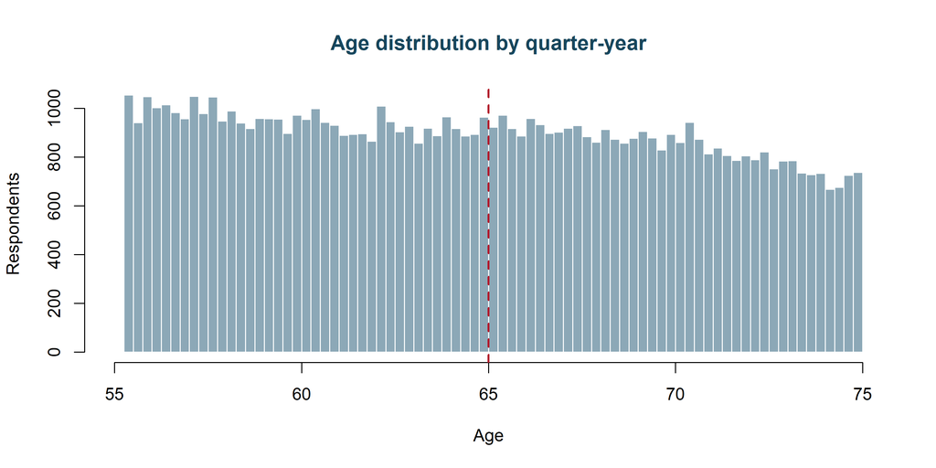

Respondents by quarter-year of age, before any outcome is required. The dashed line marks age 65.

The histogram is a descriptive check of the recorded age distribution, not a formal density test. The 65.00 cell has 923 respondents, 0.99 times the average of the two cells on either side. Whole-year ages make up 24.3% of the sample, against 25% if there were no rounding to whole years. There is no visible pile-up of respondents at 65. Because nobody can choose their age, any bunching would point to survey reporting problems rather than manipulation.

# 4 Check 2: covariate balance

If people just above 65 are the same kind of people as those just below, characteristics fixed before 65 should not jump at the cutoff. We test sex, race/ethnicity, below-high-school education and region. One category from each exhaustive set is omitted (other non-Hispanic race; West). Each outcome’s sample is tested separately, because the estimation report uses each sample for its own outcome.

## 4.1 RD estimates

Jumps in percentage points. Holm p-values adjust for the eight tests within each sample. N left / right counts respondents below 65 and at 65 or above within the window. Education checks have fewer, because education is missing for some respondents.

| Covariate | Doctor: jump | Doctor: 95% CI | Doctor: Holm p | Doctor: N left / right | Hospital: jump | Hospital: 95% CI | Hospital: Holm p | Hospital: N left / right |
| --- | --- | --- | --- | --- | --- | --- | --- | --- |
| Female | -0.92 | [-3.30, 1.47] | 1 | 17,231 / 17,741 | -0.81 | [-3.18, 1.55] | 1 | 17,496 / 18,017 |
| White non-Hispanic | 0.28 | [-1.51, 2.07] | 1 | 17,231 / 17,741 | 0.34 | [-1.44, 2.12] | 1 | 17,496 / 18,017 |
| Black non-Hispanic | 0.21 | [-1.07, 1.49] | 1 | 17,231 / 17,741 | 0.13 | [-1.14, 1.41] | 1 | 17,496 / 18,017 |
| Hispanic | -0.16 | [-1.12, 0.79] | 1 | 17,231 / 17,741 | -0.02 | [-0.97, 0.93] | 1 | 17,496 / 18,017 |
| Below high school | 0.59 | [-1.61, 2.78] | 1 | 16,988 / 17,480 | 0.58 | [-1.60, 2.76] | 1 | 17,201 / 17,719 |
| Northeast | 0.66 | [-1.29, 2.61] | 1 | 17,231 / 17,741 | 0.74 | [-1.20, 2.67] | 1 | 17,496 / 18,017 |
| Midwest | -1.22 | [-3.24, 0.80] | 1 | 17,231 / 17,741 | -1.41 | [-3.42, 0.59] | 1 | 17,496 / 18,017 |
| South | 1.63 | [-0.64, 3.90] | 1 | 17,231 / 17,741 | 1.75 | [-0.51, 4.00] | 1 | 17,496 / 18,017 |

Of the 16 tests, 0 reject zero at 5% before adjustment and 0 after the Holm adjustment.

## 4.2 Binned plots

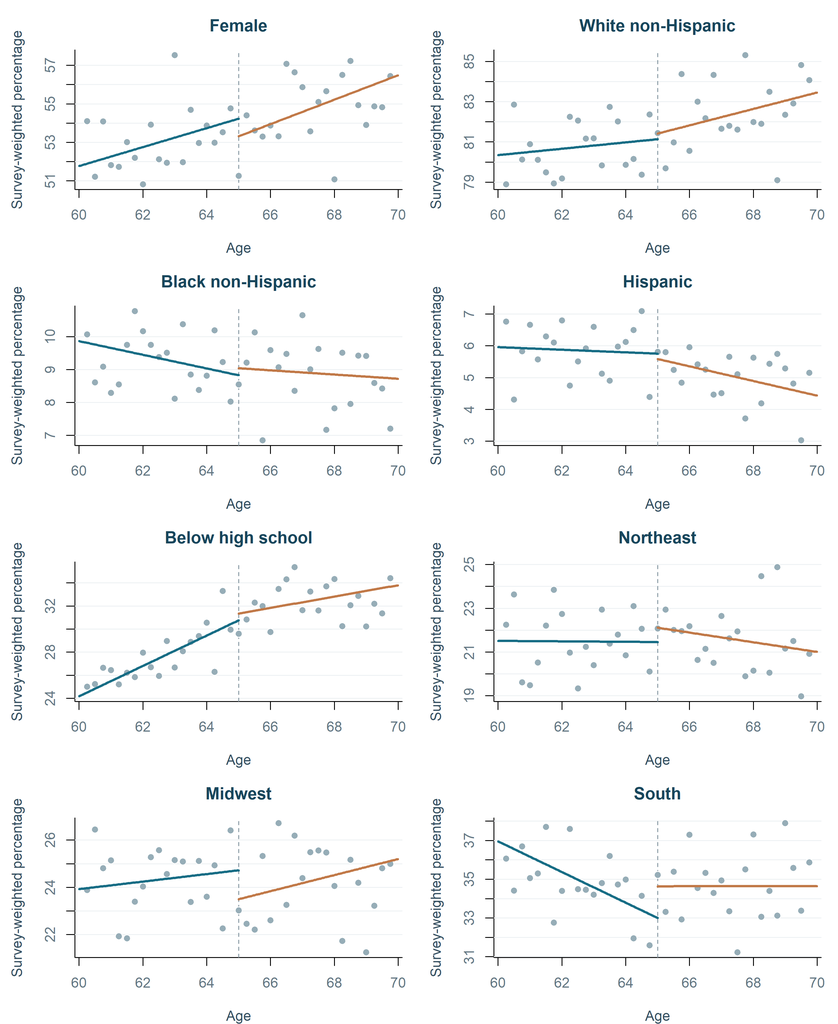

Covariates against age in the doctor-visit sample, main five-year bandwidth. Points are weighted quarter-age means; lines are local linear fits on each side of 65.

## 4.3 Bandwidth sensitivity

Doctor-visit sample. Jumps in percentage points, with p-values in brackets. The last row gives N left / right for each bandwidth; education checks have slightly fewer.

| Covariate | +/-3 years | +/-4 years | +/-5 years | +/-6 years | +/-7 years |
| --- | --- | --- | --- | --- | --- |
| Female | -1.44 (0.363) | -1.24 (0.365) | -0.92 (0.451) | -0.67 (0.548) | -0.28 (0.784) |
| White non-Hispanic | 0.25 (0.834) | 0.17 (0.869) | 0.28 (0.758) | 0.23 (0.786) | 0.04 (0.963) |
| Black non-Hispanic | 0.17 (0.844) | 0.37 (0.609) | 0.21 (0.746) | 0.19 (0.750) | 0.24 (0.663) |
| Hispanic | -0.05 (0.932) | -0.09 (0.867) | -0.16 (0.737) | -0.21 (0.645) | -0.18 (0.665) |
| Below high school | -0.66 (0.651) | -0.04 (0.975) | 0.59 (0.599) | 0.79 (0.439) | 1.06 (0.261) |
| Northeast | 0.98 (0.446) | 0.89 (0.423) | 0.66 (0.508) | 0.55 (0.547) | 0.28 (0.739) |
| Midwest | -1.89 (0.160) | -1.65 (0.153) | -1.22 (0.236) | -0.92 (0.325) | -0.79 (0.363) |
| South | 2.53 (0.092) | 2.05 (0.115) | 1.63 (0.160) | 1.21 (0.251) | 0.99 (0.315) |
| N left / right | 9,913 / 10,813 | 13,520 / 14,287 | 17,231 / 17,741 | 20,937 / 21,187 | 24,624 / 24,392 |

## 4.4 Exploratory check: covariate index

We regress each outcome on the covariates using only respondents below 65 in that outcome’s sample, then test for a discontinuity in the predicted outcome. This combines the covariates in proportion to how much they matter for healthcare use. It is an exploratory diagnostic, not a formal joint test: imbalances can cancel in the index, and the HC1 intervals treat the fitted index weights as fixed.

| Specification | Jump (pp) | 95% CI (pp) | p-value | Rate below cutoff | Relative change | N | N left | N right |
| --- | --- | --- | --- | --- | --- | --- | --- | --- |
| Predicted doctor visit (covariate index) | -0.04 | [-0.25, 0.17] | 0.696 | 81.3% | -0.1% | 34,468 | 16,988 | 17,480 |
| Predicted hospital stay (covariate index) | 0.05 | [-0.03, 0.14] | 0.228 | 9.8% | 0.6% | 34,920 | 17,201 | 17,719 |

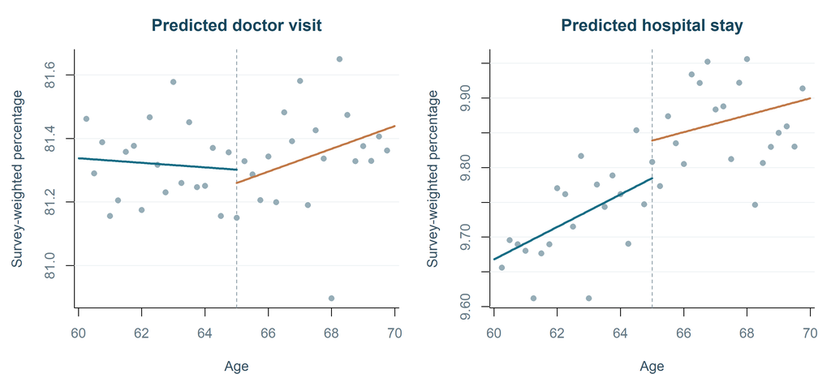

Outcomes predicted from covariates alone, each in its own outcome sample. A jump would mean the mix of people changes at 65 in a way that matters for healthcare use.

No covariate jumps significantly at 65 in either sample after adjusting for multiple tests. The covariate index for doctor visits changes by -0.04 pp at 65 (p = 0.696), and the index for hospital stays by 0.05 pp (p = 0.228). Based on observed characteristics, the people on either side of 65 look comparable in the ways that matter for healthcare use. Insignificant jumps are consistent with balance but do not prove it, and these tests say nothing about unobserved characteristics.

# 5 Check 3: retirement and employment at 65

During 1992–1996, 65 was the Social Security full retirement age. If many people stopped working at 65, retirement could raise doctor visits on its own through more free time or a change in income or insurance. The age-65 jump would then mix Medicare and retirement. Retirement caused *by* Medicare is part of the eligibility effect; the concern is retirement driven by other age-65 incentives.

The data have no retirement variable. `emp` records whether the respondent worked in the past two weeks, so it is the closest available measure. Employment is tested on all respondents, since everyone has an employment answer.

## 5.1 Employment at 65

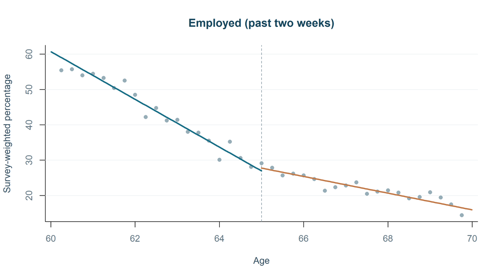

Employment around age 65. Points are weighted quarter-age means; lines are local linear fits.

| Specification | Jump (pp) | 95% CI (pp) | p-value | Rate below cutoff | Relative change | N | N left | N right |
| --- | --- | --- | --- | --- | --- | --- | --- | --- |
| +/-3 years | 1.30 | [-1.48, 4.08] | 0.359 | 27.2% | 4.8% | 21,057 | 10,070 | 10,987 |
| +/-4 years | 1.22 | [-1.18, 3.62] | 0.320 | 26.9% | 4.5% | 28,243 | 13,734 | 14,509 |
| +/-5 years | 0.81 | [-1.34, 2.95] | 0.460 | 27.0% | 3.0% | 35,513 | 17,496 | 18,017 |
| +/-6 years | 0.23 | [-1.72, 2.19] | 0.814 | 27.5% | 0.9% | 42,783 | 21,277 | 21,506 |
| +/-7 years | -0.55 | [-2.36, 1.26] | 0.553 | 28.2% | -1.9% | 49,794 | 25,051 | 24,743 |

The employment jump at 65 is **0.81 percentage points** (95% CI [-1.34, 2.95]; p = 0.46), against a fitted employment rate of 27.0% just below 65. There is no statistically significant employment change at 65. Under this specification, the interval excludes an employment drop larger than 1.34 pp. The result is insignificant at every bandwidth from 3 to 7 years. In the doctor-visit sample the jump is 0.73 pp (95% CI [-1.43, 2.89]).

## 5.2 Falsification tests

The donut drops the potentially misclassified 65.00 cell. The placebo cutoffs at 60 and 70 use two-year windows, which keep each window clear of both 62 and 65.

| Specification | Jump (pp) | 95% CI (pp) | p-value | Rate below cutoff | Relative change | N | N left | N right |
| --- | --- | --- | --- | --- | --- | --- | --- | --- |
| Donut: drop the 65.00 cell (+/-5 years) | 0.32 | [-1.94, 2.57] | 0.784 | 27.0% | 1.2% | 34,590 | 17,496 | 17,094 |
| Placebo at 60 (+/-2 years) | 1.17 | [-2.62, 4.97] | 0.545 | 56.4% | 2.1% | 13,971 | 6,600 | 7,371 |
| Placebo at 70 (+/-2 years) | 1.21 | [-1.70, 4.12] | 0.416 | 14.7% | 8.2% | 12,842 | 6,116 | 6,726 |

## 5.3 Positive control: age 62

Age 62 is the earliest age for claiming Social Security retirement benefits, so employment is known to fall there. If our specification finds that drop, it can detect a retirement change of this kind. This does not guarantee equal power at 65.

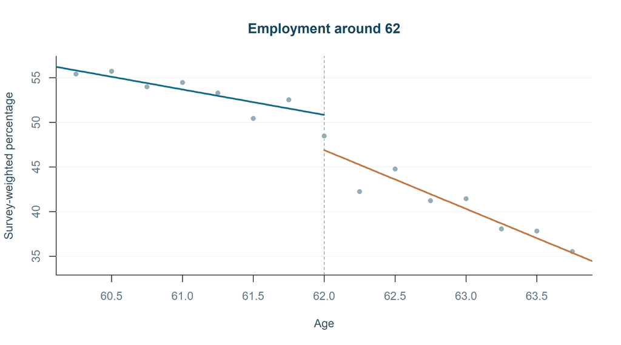

Employment around age 62 (two-year window), where early Social Security claiming begins.

| Specification | Jump (pp) | 95% CI (pp) | p-value | Rate below cutoff | Relative change | N | N left | N right |
| --- | --- | --- | --- | --- | --- | --- | --- | --- |
| Positive control at 62 (+/-2 years) | -3.95 | [-7.82, -0.09] | 0.0452 | 50.8% | -7.8% | 13,833 | 6,416 | 7,417 |

At 62, employment changes by **-3.95 pp** (95% CI [-7.82, -0.09]; p = 0.0452). The test detects the expected retirement drop at 62, so the absence of a drop at 65 is informative.

**What employment can and cannot show.** An insignificant employment discontinuity means that this specification does not detect a net change; its confidence interval still permits changes. It does not rule out small changes, offsetting moves into and out of work, or pension and income changes among people who had already retired.

# 6 Check 4: who gains insurance at 65

## 6.1 The prediction

Medicare eligibility can affect previously uninsured people who gain coverage and already-insured people whose coverage changes. For **doctor visits**, we explore whether groups with larger gains in any insurance show larger utilisation increases, consistent with improved access among the previously uninsured. This is an exploratory hypothesis, not a necessary implication of Medicare eligibility.

We do **not impose the same ordering on hospital stays**. Previously insured people may respond to changes in coverage generosity, supplemental insurance or the cost of particular procedures. Card, Dobkin and Maestas (2008) find larger responses for some expensive hospital procedures among previously insured groups. Our outcome is any overnight hospital stay, not those specific procedures. A hospital pattern that does not follow gains in any coverage therefore does not by itself contradict an insurance mechanism.

We compare four race-by-education groups. The jump in **any insurance coverage** (`covered2`) measures a net change in the insured share, not a direct count of individual gainers. Medicare coverage changes include both newly insured respondents and changes in existing coverage. Employment jumps provide a separate, indirect comparison for a possible retirement channel. The estimation report compares these descriptive patterns with the outcome jumps.

## 6.3 Jumps by group

**Doctor-visit sample**

| Group | N | N left / right | Uninsured before 65 | Medicare before 65 | Coverage gain at 65 (pp) | Medicare jump (pp) | Employment jump (pp) |
| --- | --- | --- | --- | --- | --- | --- | --- |
| White non-Hispanic, high education | 18,796 | 9,364 / 9,432 | 6.9% | 12.1% | 5.1 [3.8, 6.4] | 64.0 [61.6, 66.5] | 0.7 [-2.3, 3.8] |
| White non-Hispanic, low education | 6,520 | 2,863 / 3,657 | 13.6% | 21.0% | 9.5 [6.6, 12.4] | 57.9 [53.3, 62.4] | 1.9 [-2.6, 6.3] |
| Other race/ethnicity, high education | 3,380 | 1,857 / 1,523 | 14.5% | 13.1% | 8.3 [3.9, 12.8] | 58.4 [52.2, 64.7] | -4.4 [-12.0, 3.1] |
| Other race/ethnicity, low education | 3,760 | 1,808 / 1,952 | 28.1% | 23.0% | 17.7 [11.8, 23.5] | 44.7 [37.9, 51.6] | 0.2 [-5.7, 6.1] |

**Hospital-stay sample**

| Group | N | N left / right | Uninsured before 65 | Medicare before 65 | Coverage gain at 65 (pp) | Medicare jump (pp) | Employment jump (pp) |
| --- | --- | --- | --- | --- | --- | --- | --- |
| White non-Hispanic, high education | 18,982 | 9,447 / 9,535 | 6.8% | 12.1% | 5.1 [3.8, 6.3] | 63.9 [61.5, 66.4] | 0.6 [-2.4, 3.6] |
| White non-Hispanic, low education | 6,593 | 2,896 / 3,697 | 13.7% | 21.0% | 9.8 [6.9, 12.7] | 58.1 [53.6, 62.6] | 1.7 [-2.7, 6.1] |
| Other race/ethnicity, high education | 3,438 | 1,886 / 1,552 | 14.8% | 13.3% | 8.8 [4.3, 13.2] | 58.5 [52.3, 64.7] | -3.6 [-11.1, 3.9] |
| Other race/ethnicity, low education | 3,815 | 1,831 / 1,984 | 28.1% | 22.8% | 16.7 [10.6, 22.8] | 44.3 [37.4, 51.2] | 0.6 [-5.5, 6.6] |

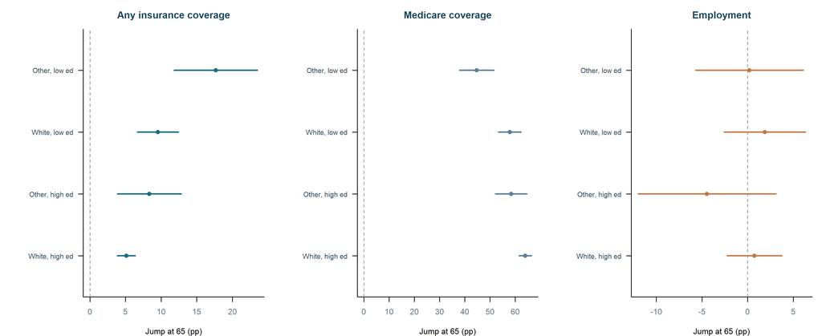

Jumps at 65 by group in the doctor-visit sample, with 95% confidence intervals. Groups are ordered by the coverage gain.

**Exploratory doctor-visit comparison.** Coverage rises most at 65 for **Other race/ethnicity, low education** (17.7 pp) and least for **White non-Hispanic, high education** (5.1 pp). A larger doctor-visit increase in the former group would be consistent with a newly insured access channel, subject to differences in treatment responses across groups.

The middle-group coverage contrast has p = 0.66; nonrejection does not establish equal coverage gains. Hospital outcomes are compared separately without requiring this ordering, since changes in generosity can matter for previously insured respondents.

## 6.4 Secondary comparison: the Medicare jump

Medicare coverage rises by 60.2 pp at 65, compared with 7.5 pp for any coverage. The larger Medicare discontinuity is consistent with changes in insurance arrangements among previously insured respondents as well as newly gained coverage. These separate fits may use different response samples. Their ratio does not identify a switcher share, and no percentage of individual transitions is inferred.

The Medicare-jump ordering is White non-Hispanic, high education > Other race/ethnicity, high education > White non-Hispanic, low education > Other race/ethnicity, low education. Different coverage rankings can reflect prior Medicare participation, insurance switching and other group differences. Neither ranking alone identifies which mechanism determines healthcare utilisation. With four groups, these comparisons are descriptive and subject to estimation uncertainty.

## 6.5 Retirement alternative

Larger utilisation increases where employment falls more would be consistent with a retirement channel, but heterogeneous responses and offsetting employment flows can break this ordering. Employment falls most for Other race/ethnicity, high education (-4.4 pp). In the other three groups it changes by between 0.2 and 1.9 pp. No group shows a significant employment change at 65. The group with the largest employment drop is not the group with the largest coverage gain, so the two channels make different predictions that the estimation report can compare.

# 7 Summary

## 7.1 Diagnostic summary

| Check | What it tests | Result | Verdict |
| --- | --- | --- | --- |
| Heaping in age | Sorting or rounding of age around 65 | 65.00 cell is 0.99 times its neighbours; 24.3% whole-year ages | No visible pile-up |
| Response rates | Observed response-rate discontinuities | 0 of 4 significant after Holm | No rejection |
| Covariate balance | Comparable people on each side | 0 of 16 significant after Holm | No rejection |
| Covariate index | Combined imbalance relevant to healthcare use | Doctor visits -0.04 pp (p = 0.696); hospital 0.05 pp (p = 0.228) | No rejection |
| Employment at 65 | Retirement at 65 | 0.81 pp, CI [-1.34, 2.95], p = 0.46 | No rejection |
| Employment falsification | Donut and placebo cutoffs for employment | 0 of 3 significant | No rejection |
| Positive control at 62 | Whether the employment test can detect retirement | -3.95 pp, p = 0.0452 | Drop detected |
| Subgroup prediction | Exploratory doctor-visit access hypothesis | Largest coverage gain: Other race/ethnicity, low education; smallest: White non-Hispanic, high education | Tested in estimation report |

**What the checks support.** We do not detect a statistically significant employment discontinuity at 65; a decline is detected at 62, but that does not establish equal power at 65. The covariate and response-rate tests do not reject continuity under the reported specifications. Doctor-visit patterns aligned with coverage gains would be consistent with improved access; hospital patterns may also reflect coverage generosity. Neither pattern alone separates insurance and retirement causally. These checks support the continuity assumption but cannot prove it.

## 7.2 Remaining assumptions

These checks support continuity but cannot prove it. Three things remain assumptions:

- **Unobserved characteristics are smooth at 65.** Balance in sex, race, education and region does not guarantee balance in, for example, health status or income.
- **No other age-65 channel.** Flat employment does not rule out small retirement effects, offsetting flows, or pension and income changes among people already retired.
- **Missing answers are not selective.** Nonrejection of response-rate discontinuities does not establish identical selection processes or identify the composition and outcomes of nonrespondents.

### 7.2.1 SUTVA and interference

SUTVA requires a well-defined treatment and no interference between individuals. Treatment is eligibility under the age-65 Medicare policy, rather than enrollment in a particular insurance plan. Gaining insurance, switching plans and obtaining supplemental coverage are responses included in the overall eligibility ITT; these differences do not themselves violate the assumption.

SUTVA cannot be directly verified with these data. Observing a respondent’s insurance and healthcare use does not reveal how their utilisation would change if someone else’s eligibility changed while their own stayed fixed. Household links and spouse ages could support an indirect check for spousal spillovers, but those variables are absent from the data. We therefore maintain no-interference as an assumption. Household insurance decisions and provider behaviour could create spillovers; for the local RD comparison, we assume that exposure to these effects varies smoothly with the respondent’s own age around 65.

## 7.3 Estimation inputs

- **Specification:** local linear, 5-year main bandwidth, alternatives of 3, 4, 6, 7 years, triangular kernel times the supplied survey weights, survey-year fixed effects, HC1 standard errors with normal critical values (shared through `rd_functions.R`).
- **Samples:** each outcome uses its own sample. Subgroup comparisons use the matched samples built by `subgroup_sample()`.
- **Exploratory doctor-visit hypothesis:** larger jumps for Other race/ethnicity, low education and smallest for White non-Hispanic, high education, would be consistent with the coverage-gain mechanism. No common ordering is imposed on hospital stays; coverage generosity may also matter.
- **Donut RD:** drop the potentially misclassified 65.00 cell. A wider donut (64.75–65.25) addresses people delaying care until 65.

## 7.4 References

Card, D., Dobkin, C. and Maestas, N. (2008). [The Impact of Nearly Universal Insurance Coverage on Health Care Utilization: Evidence from Medicare](https://pmc.ncbi.nlm.nih.gov/articles/PMC2600774/). *American Economic Review*, 98(5), 2242-2258.

Hahn, J., Todd, P. and van der Klaauw, W. (2001). Identification and Estimation of Treatment Effects with a Regression-Discontinuity Design. *Econometrica*, 69(1), 201-209.